# Risk Factor Analysis

## Outcome Variable

**Outcome Variable:** whz

## Predictor Variables

**Intervention Variable:** feducyrs

**Adjustment Set:**

- arm
- W_mage
- meducyrs
- W_mhtcm
- W_gagebrth
- W_birthwt
- W_birthlen
- single
- delta_W_mage
- delta_meducyrs
- delta_W_mhtcm
- delta_W_gagebrth
- delta_W_birthwt
- delta_W_birthlen
- delta_single

## Stratifying Variables

The analysis was stratified on these variable(s):

- agecat
- studyid
- country

## Data Summary

| agecat | studyid | country | feducyrs | n_cell | n |
| --- | --- | --- | --- | --- | --- |
| Birth | ki0047075b-MAL-ED | BANGLADESH | High | 49 | 134 |
| Birth | ki0047075b-MAL-ED | BANGLADESH | Low | 35 | 134 |
| Birth | ki0047075b-MAL-ED | BANGLADESH | Medium | 50 | 134 |
| Birth | ki0047075b-MAL-ED | INDIA | High | 38 | 121 |
| Birth | ki0047075b-MAL-ED | INDIA | Low | 48 | 121 |
| Birth | ki0047075b-MAL-ED | INDIA | Medium | 35 | 121 |
| Birth | ki0047075b-MAL-ED | NEPAL | High | 27 | 64 |
| Birth | ki0047075b-MAL-ED | NEPAL | Low | 18 | 64 |
| Birth | ki0047075b-MAL-ED | NEPAL | Medium | 19 | 64 |
| Birth | ki0047075b-MAL-ED | PERU | High | 112 | 230 |
| Birth | ki0047075b-MAL-ED | PERU | Low | 63 | 230 |
| Birth | ki0047075b-MAL-ED | PERU | Medium | 55 | 230 |
| Birth | ki0047075b-MAL-ED | SOUTH AFRICA | High | 35 | 91 |
| Birth | ki0047075b-MAL-ED | SOUTH AFRICA | Low | 30 | 91 |
| Birth | ki0047075b-MAL-ED | SOUTH AFRICA | Medium | 26 | 91 |
| Birth | ki0047075b-MAL-ED | TANZANIA, UNITED REPUBLIC OF | High | 63 | 96 |
| Birth | ki0047075b-MAL-ED | TANZANIA, UNITED REPUBLIC OF | Low | 27 | 96 |
| Birth | ki0047075b-MAL-ED | TANZANIA, UNITED REPUBLIC OF | Medium | 6 | 96 |
| Birth | ki1000304b-SAS-CompFeed | INDIA | High | 33 | 166 |
| Birth | ki1000304b-SAS-CompFeed | INDIA | Low | 68 | 166 |
| Birth | ki1000304b-SAS-CompFeed | INDIA | Medium | 65 | 166 |
| Birth | ki1017093c-NIH-Crypto | BANGLADESH | High | 7 | 23 |
| Birth | ki1017093c-NIH-Crypto | BANGLADESH | Low | 11 | 23 |
| Birth | ki1017093c-NIH-Crypto | BANGLADESH | Medium | 5 | 23 |
| Birth | ki1119695-PROBIT | BELARUS | High | 2050 | 13359 |
| Birth | ki1119695-PROBIT | BELARUS | Low | 5294 | 13359 |
| Birth | ki1119695-PROBIT | BELARUS | Medium | 6015 | 13359 |
| Birth | ki1126311-ZVITAMBO | ZIMBABWE | High | 914 | 12572 |
| Birth | ki1126311-ZVITAMBO | ZIMBABWE | Low | 2090 | 12572 |
| Birth | ki1126311-ZVITAMBO | ZIMBABWE | Medium | 9568 | 12572 |

[output cut: 129 more lines]

The following strata were considered:

- agecat: 24 months, studyid: ki0047075b-MAL-ED, country: BANGLADESH
- agecat: 24 months, studyid: ki0047075b-MAL-ED, country: INDIA
- agecat: 24 months, studyid: ki0047075b-MAL-ED, country: NEPAL
- agecat: 24 months, studyid: ki0047075b-MAL-ED, country: PERU
- agecat: 24 months, studyid: ki0047075b-MAL-ED, country: SOUTH AFRICA
- agecat: 24 months, studyid: ki0047075b-MAL-ED, country: TANZANIA, UNITED REPUBLIC OF
- agecat: 24 months, studyid: ki1017093b-PROVIDE, country: BANGLADESH
- agecat: 24 months, studyid: ki1017093c-NIH-Crypto, country: BANGLADESH
- agecat: 24 months, studyid: ki1066203-TanzaniaChild2, country: TANZANIA, UNITED REPUBLIC OF
- agecat: 24 months, studyid: ki1113344-GMS-Nepal, country: NEPAL
- agecat: 24 months, studyid: ki1119695-PROBIT, country: BELARUS
- agecat: 24 months, studyid: ki1126311-ZVITAMBO, country: ZIMBABWE
- agecat: 24 months, studyid: ki1135781-COHORTS, country: GUATEMALA
- agecat: 24 months, studyid: ki1135781-COHORTS, country: INDIA
- agecat: 24 months, studyid: ki1135781-COHORTS, country: PHILIPPINES
- agecat: 24 months, studyid: ki1148112-LCNI-5, country: MALAWI
- agecat: 24 months, studyid: kiGH5241-JiVitA-3, country: BANGLADESH
- agecat: 24 months, studyid: kiGH5241-JiVitA-4, country: BANGLADESH
- agecat: 6 months, studyid: ki0047075b-MAL-ED, country: BANGLADESH
- agecat: 6 months, studyid: ki0047075b-MAL-ED, country: INDIA
- agecat: 6 months, studyid: ki0047075b-MAL-ED, country: NEPAL
- agecat: 6 months, studyid: ki0047075b-MAL-ED, country: PERU
- agecat: 6 months, studyid: ki0047075b-MAL-ED, country: SOUTH AFRICA
- agecat: 6 months, studyid: ki0047075b-MAL-ED, country: TANZANIA, UNITED REPUBLIC OF
- agecat: 6 months, studyid: ki1000304b-SAS-CompFeed, country: INDIA
- agecat: 6 months, studyid: ki1000304b-SAS-FoodSuppl, country: INDIA
- agecat: 6 months, studyid: ki1017093b-PROVIDE, country: BANGLADESH
- agecat: 6 months, studyid: ki1017093c-NIH-Crypto, country: BANGLADESH
- agecat: 6 months, studyid: ki1066203-TanzaniaChild2, country: TANZANIA, UNITED REPUBLIC OF
- agecat: 6 months, studyid: ki1113344-GMS-Nepal, country: NEPAL
- agecat: 6 months, studyid: ki1119695-PROBIT, country: BELARUS
- agecat: 6 months, studyid: ki1126311-ZVITAMBO, country: ZIMBABWE
- agecat: 6 months, studyid: ki1135781-COHORTS, country: GUATEMALA
- agecat: 6 months, studyid: ki1135781-COHORTS, country: INDIA
- agecat: 6 months, studyid: ki1135781-COHORTS, country: PHILIPPINES
- agecat: 6 months, studyid: ki1148112-LCNI-5, country: MALAWI
- agecat: 6 months, studyid: kiGH5241-JiVitA-3, country: BANGLADESH
- agecat: 6 months, studyid: kiGH5241-JiVitA-4, country: BANGLADESH
- agecat: Birth, studyid: ki0047075b-MAL-ED, country: BANGLADESH
- agecat: Birth, studyid: ki0047075b-MAL-ED, country: INDIA
- agecat: Birth, studyid: ki0047075b-MAL-ED, country: NEPAL
- agecat: Birth, studyid: ki0047075b-MAL-ED, country: PERU
- agecat: Birth, studyid: ki0047075b-MAL-ED, country: SOUTH AFRICA
- agecat: Birth, studyid: ki0047075b-MAL-ED, country: TANZANIA, UNITED REPUBLIC OF
- agecat: Birth, studyid: ki1000304b-SAS-CompFeed, country: INDIA
- agecat: Birth, studyid: ki1017093c-NIH-Crypto, country: BANGLADESH
- agecat: Birth, studyid: ki1119695-PROBIT, country: BELARUS
- agecat: Birth, studyid: ki1126311-ZVITAMBO, country: ZIMBABWE
- agecat: Birth, studyid: ki1135781-COHORTS, country: GUATEMALA
- agecat: Birth, studyid: ki1135781-COHORTS, country: INDIA
- agecat: Birth, studyid: ki1135781-COHORTS, country: PHILIPPINES
- agecat: Birth, studyid: kiGH5241-JiVitA-3, country: BANGLADESH
- agecat: Birth, studyid: kiGH5241-JiVitA-4, country: BANGLADESH

### Dropped Strata

Some strata were dropped due to rare outcomes:

- agecat: 24 months, studyid: ki1066203-TanzaniaChild2, country: TANZANIA, UNITED REPUBLIC OF

## Methods Detail

We’re interested in the causal parameters $E[Y_a]$ for all values of $a \in \mathcal{A}$. These parameters represent the mean outcome if, possibly contrary to fact, we intervened to set all units to have $A=a$. Under the randomization and positivity assumptions, these are identified by the statistical parameters $\psi_a=E_W[E_{Y|A,W}(Y|A=a,W)]$. In addition, we’re interested in the mean of $Y$, $E[Y]$ under no intervention (the observed mean). We will estimate these parameters by using SuperLearner to fit the relevant likelihood factors – $E_{Y|A,W}(Y|A=a,W)$ and $p(A=a|W)$, and then updating our likelihood fit using a joint TMLE.

For unadjusted analyses ($W=\{\}$), initial likelihoods were estimated using Lrnr_glm to estimate the simple $E(Y|A)$ and Lrnr_mean to estimate $p(A)$. For adjusted analyses, a small library containing Lrnr_glmnet, Lrnr_xgboost, and Lrnr_mean was used.

Having estimated these parameters, we will then use the delta method to estimate relative risks and attributable risks relative to a prespecified baseline level of $A$.

# Results Detail

## Results Plots

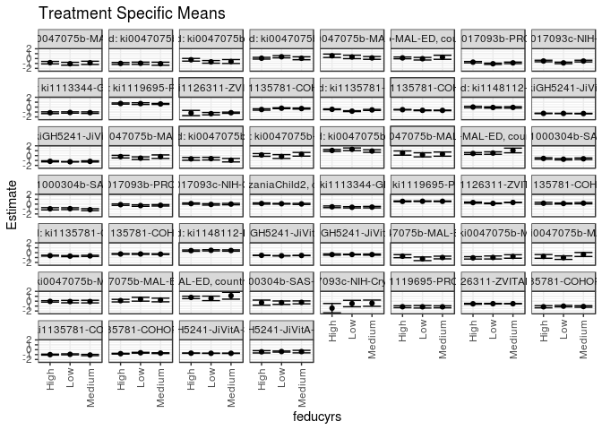

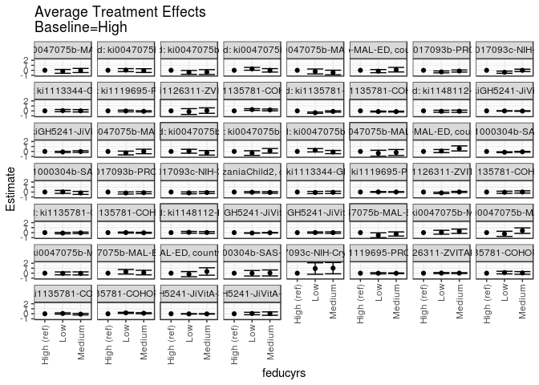

[figure not shown]

## Results Table

### Parameter: TSM

| agecat | studyid | country | intervention_level | baseline_level | estimate | ci_lower | ci_upper |
| --- | --- | --- | --- | --- | --- | --- | --- |
| Birth | ki0047075b-MAL-ED | BANGLADESH | High | NA | -0.7171102 | -1.0268648 | -0.4073555 |
| Birth | ki0047075b-MAL-ED | BANGLADESH | Low | NA | -1.2464511 | -1.6156011 | -0.8773010 |
| Birth | ki0047075b-MAL-ED | BANGLADESH | Medium | NA | -0.9906031 | -1.2659828 | -0.7152234 |
| Birth | ki0047075b-MAL-ED | INDIA | High | NA | -1.0571702 | -1.2986339 | -0.8157066 |
| Birth | ki0047075b-MAL-ED | INDIA | Low | NA | -0.9832507 | -1.2865546 | -0.6799467 |
| Birth | ki0047075b-MAL-ED | INDIA | Medium | NA | -0.7827368 | -1.1385973 | -0.4268763 |
| Birth | ki0047075b-MAL-ED | NEPAL | High | NA | -0.7679489 | -1.1488283 | -0.3870694 |
| Birth | ki0047075b-MAL-ED | NEPAL | Low | NA | -1.0195140 | -1.3759305 | -0.6630974 |
| Birth | ki0047075b-MAL-ED | NEPAL | Medium | NA | -0.3721166 | -0.7761293 | 0.0318961 |
| Birth | ki0047075b-MAL-ED | PERU | High | NA | -0.0415464 | -0.1901853 | 0.1070925 |
| Birth | ki0047075b-MAL-ED | PERU | Low | NA | -0.0802089 | -0.3277514 | 0.1673336 |
| Birth | ki0047075b-MAL-ED | PERU | Medium | NA | -0.0822261 | -0.3490040 | 0.1845518 |
| Birth | ki0047075b-MAL-ED | SOUTH AFRICA | High | NA | 0.1102058 | -0.1511293 | 0.3715409 |
| Birth | ki0047075b-MAL-ED | SOUTH AFRICA | Low | NA | 0.3937263 | 0.0095093 | 0.7779433 |
| Birth | ki0047075b-MAL-ED | SOUTH AFRICA | Medium | NA | 0.2420618 | -0.1302170 | 0.6143407 |
| Birth | ki0047075b-MAL-ED | TANZANIA, UNITED REPUBLIC OF | High | NA | 0.7669841 | 0.5145747 | 1.0193936 |
| Birth | ki0047075b-MAL-ED | TANZANIA, UNITED REPUBLIC OF | Low | NA | 0.5718519 | 0.1177775 | 1.0259262 |
| Birth | ki0047075b-MAL-ED | TANZANIA, UNITED REPUBLIC OF | Medium | NA | 1.1133333 | 0.4136753 | 1.8129914 |
| Birth | ki1000304b-SAS-CompFeed | INDIA | High | NA | -0.2967595 | -0.8133506 | 0.2198315 |
| Birth | ki1000304b-SAS-CompFeed | INDIA | Low | NA | -0.3082328 | -0.6588317 | 0.0423662 |
| Birth | ki1000304b-SAS-CompFeed | INDIA | Medium | NA | -0.2437014 | -0.5453082 | 0.0579054 |
| Birth | ki1017093c-NIH-Crypto | BANGLADESH | High | NA | -1.4200000 | -2.3657984 | -0.4742016 |
| Birth | ki1017093c-NIH-Crypto | BANGLADESH | Low | NA | -0.4800000 | -1.1381374 | 0.1781374 |
| Birth | ki1017093c-NIH-Crypto | BANGLADESH | Medium | NA | -0.4100000 | -1.0437501 | 0.2237501 |
| Birth | ki1119695-PROBIT | BELARUS | High | NA | -1.1306179 | -1.3296188 | -0.9316170 |
| Birth | ki1119695-PROBIT | BELARUS | Low | NA | -1.1405439 | -1.3934730 | -0.8876149 |
| Birth | ki1119695-PROBIT | BELARUS | Medium | NA | -1.1470333 | -1.3509930 | -0.9430737 |
| Birth | ki1126311-ZVITAMBO | ZIMBABWE | High | NA | -0.5335269 | -0.6243025 | -0.4427513 |
| Birth | ki1126311-ZVITAMBO | ZIMBABWE | Low | NA | -0.5128369 | -0.5787011 | -0.4469726 |
| Birth | ki1126311-ZVITAMBO | ZIMBABWE | Medium | NA | -0.5128037 | -0.5424519 | -0.4831554 |

[output cut: 126 more lines]

### Parameter: E(Y)

| agecat | studyid | country | intervention_level | baseline_level | estimate | ci_lower | ci_upper |
| --- | --- | --- | --- | --- | --- | --- | --- |
| Birth | ki0047075b-MAL-ED | BANGLADESH | NA | NA | -0.9578358 | -1.1387078 | -0.7769639 |
| Birth | ki0047075b-MAL-ED | INDIA | NA | NA | -0.9940496 | -1.1654347 | -0.8226645 |
| Birth | ki0047075b-MAL-ED | NEPAL | NA | NA | -0.6120312 | -0.8275323 | -0.3965302 |
| Birth | ki0047075b-MAL-ED | PERU | NA | NA | -0.0617391 | -0.1779184 | 0.0544402 |
| Birth | ki0047075b-MAL-ED | SOUTH AFRICA | NA | NA | 0.1956044 | -0.0084906 | 0.3996994 |
| Birth | ki0047075b-MAL-ED | TANZANIA, UNITED REPUBLIC OF | NA | NA | 0.7337500 | 0.5184571 | 0.9490429 |
| Birth | ki1000304b-SAS-CompFeed | INDIA | NA | NA | -0.2697590 | -0.5399211 | 0.0004030 |
| Birth | ki1017093c-NIH-Crypto | BANGLADESH | NA | NA | -0.7508696 | -1.2358912 | -0.2658480 |
| Birth | ki1119695-PROBIT | BELARUS | NA | NA | -1.1411895 | -1.3517005 | -0.9306784 |
| Birth | ki1126311-ZVITAMBO | ZIMBABWE | NA | NA | -0.5089119 | -0.5350685 | -0.4827552 |
| Birth | ki1135781-COHORTS | GUATEMALA | NA | NA | -1.0475905 | -1.1510656 | -0.9441155 |
| Birth | ki1135781-COHORTS | INDIA | NA | NA | -1.0020759 | -1.0646599 | -0.9394920 |
| Birth | ki1135781-COHORTS | PHILIPPINES | NA | NA | -0.7218585 | -0.7694262 | -0.6742908 |
| Birth | kiGH5241-JiVitA-3 | BANGLADESH | NA | NA | -0.7212256 | -0.7411702 | -0.7012810 |
| Birth | kiGH5241-JiVitA-4 | BANGLADESH | NA | NA | -0.3724538 | -0.4743874 | -0.2705203 |
| 6 months | ki0047075b-MAL-ED | BANGLADESH | NA | NA | -0.3053662 | -0.4828374 | -0.1278949 |
| 6 months | ki0047075b-MAL-ED | INDIA | NA | NA | -0.7164734 | -0.8860809 | -0.5468660 |
| 6 months | ki0047075b-MAL-ED | NEPAL | NA | NA | 0.0313158 | -0.1673661 | 0.2299977 |
| 6 months | ki0047075b-MAL-ED | PERU | NA | NA | 1.0866741 | 0.9521834 | 1.2211648 |
| 6 months | ki0047075b-MAL-ED | SOUTH AFRICA | NA | NA | 0.3830435 | 0.1435272 | 0.6225598 |
| 6 months | ki0047075b-MAL-ED | TANZANIA, UNITED REPUBLIC OF | NA | NA | 0.5218823 | 0.3795317 | 0.6642328 |
| 6 months | ki1000304b-SAS-CompFeed | INDIA | NA | NA | -0.6641059 | -0.8040033 | -0.5242086 |
| 6 months | ki1000304b-SAS-FoodSuppl | INDIA | NA | NA | -1.0121579 | -1.1280429 | -0.8962729 |
| 6 months | ki1017093b-PROVIDE | BANGLADESH | NA | NA | -0.2083706 | -0.2927992 | -0.1239419 |
| 6 months | ki1017093c-NIH-Crypto | BANGLADESH | NA | NA | 0.0297622 | -0.0491685 | 0.1086930 |
| 6 months | ki1066203-TanzaniaChild2 | TANZANIA, UNITED REPUBLIC OF | NA | NA | 0.0791782 | 0.0263777 | 0.1319787 |
| 6 months | ki1113344-GMS-Nepal | NEPAL | NA | NA | -0.6041489 | -0.6904591 | -0.5178387 |
| 6 months | ki1119695-PROBIT | BELARUS | NA | NA | 0.5783110 | 0.5188487 | 0.6377732 |
| 6 months | ki1126311-ZVITAMBO | ZIMBABWE | NA | NA | 0.3096296 | 0.2832594 | 0.3359998 |
| 6 months | ki1135781-COHORTS | GUATEMALA | NA | NA | 0.1987403 | 0.1250477 | 0.2724329 |
| 6 months | ki1135781-COHORTS | INDIA | NA | NA | -0.6502599 | -0.7103477 | -0.5901722 |
| 6 months | ki1135781-COHORTS | PHILIPPINES | NA | NA | -0.2839930 | -0.3263706 | -0.2416154 |
| 6 months | ki1148112-LCNI-5 | MALAWI | NA | NA | 0.4414655 | 0.3698299 | 0.5131012 |
| 6 months | kiGH5241-JiVitA-3 | BANGLADESH | NA | NA | -0.5904964 | -0.6106039 | -0.5703890 |
| 6 months | kiGH5241-JiVitA-4 | BANGLADESH | NA | NA | -0.3829461 | -0.4315670 | -0.3343252 |
| 24 months | ki0047075b-MAL-ED | BANGLADESH | NA | NA | -0.9032479 | -1.0730238 | -0.7334719 |
| 24 months | ki0047075b-MAL-ED | INDIA | NA | NA | -0.9451515 | -1.0860650 | -0.8042380 |
| 24 months | ki0047075b-MAL-ED | NEPAL | NA | NA | -0.4668132 | -0.6466833 | -0.2869431 |
| 24 months | ki0047075b-MAL-ED | PERU | NA | NA | 0.1412500 | 0.0103684 | 0.2721316 |
| 24 months | ki0047075b-MAL-ED | SOUTH AFRICA | NA | NA | 0.3713736 | 0.1781064 | 0.5646408 |
| 24 months | ki0047075b-MAL-ED | TANZANIA, UNITED REPUBLIC OF | NA | NA | 0.1027966 | -0.0354562 | 0.2410495 |
| 24 months | ki1017093b-PROVIDE | BANGLADESH | NA | NA | -0.8879412 | -0.9708680 | -0.8050144 |
| 24 months | ki1017093c-NIH-Crypto | BANGLADESH | NA | NA | -0.6103502 | -0.7050157 | -0.5156847 |
| 24 months | ki1113344-GMS-Nepal | NEPAL | NA | NA | -1.1284909 | -1.2160945 | -1.0408874 |
| 24 months | ki1119695-PROBIT | BELARUS | NA | NA | 0.6836046 | 0.5719211 | 0.7952881 |
| 24 months | ki1126311-ZVITAMBO | ZIMBABWE | NA | NA | -1.1874750 | -1.2917540 | -1.0831960 |
| 24 months | ki1135781-COHORTS | GUATEMALA | NA | NA | -0.2662176 | -0.3220630 | -0.2103721 |
| 24 months | ki1135781-COHORTS | INDIA | NA | NA | -0.6051533 | -0.6581071 | -0.5521995 |
| 24 months | ki1135781-COHORTS | PHILIPPINES | NA | NA | -0.6155714 | -0.6532287 | -0.5779140 |
| 24 months | ki1148112-LCNI-5 | MALAWI | NA | NA | -0.0443964 | -0.1269881 | 0.0381953 |
| 24 months | kiGH5241-JiVitA-3 | BANGLADESH | NA | NA | -1.2984354 | -1.3225016 | -1.2743692 |
| 24 months | kiGH5241-JiVitA-4 | BANGLADESH | NA | NA | -1.2260902 | -1.2680212 | -1.1841592 |

### Parameter: ATE

| agecat | studyid | country | intervention_level | baseline_level | estimate | ci_lower | ci_upper |
| --- | --- | --- | --- | --- | --- | --- | --- |
| Birth | ki0047075b-MAL-ED | BANGLADESH | High | High | 0.0000000 | 0.0000000 | 0.0000000 |
| Birth | ki0047075b-MAL-ED | BANGLADESH | Low | High | -0.5293409 | -1.0110447 | -0.0476371 |
| Birth | ki0047075b-MAL-ED | BANGLADESH | Medium | High | -0.2734929 | -0.6877288 | 0.1407429 |
| Birth | ki0047075b-MAL-ED | INDIA | High | High | 0.0000000 | 0.0000000 | 0.0000000 |
| Birth | ki0047075b-MAL-ED | INDIA | Low | High | 0.0739196 | -0.3147903 | 0.4626294 |
| Birth | ki0047075b-MAL-ED | INDIA | Medium | High | 0.2744335 | -0.1605091 | 0.7093760 |
| Birth | ki0047075b-MAL-ED | NEPAL | High | High | 0.0000000 | 0.0000000 | 0.0000000 |
| Birth | ki0047075b-MAL-ED | NEPAL | Low | High | -0.2515651 | -0.7740971 | 0.2709669 |
| Birth | ki0047075b-MAL-ED | NEPAL | Medium | High | 0.3958322 | -0.1591265 | 0.9507910 |
| Birth | ki0047075b-MAL-ED | PERU | High | High | 0.0000000 | 0.0000000 | 0.0000000 |
| Birth | ki0047075b-MAL-ED | PERU | Low | High | -0.0386625 | -0.3283548 | 0.2510299 |
| Birth | ki0047075b-MAL-ED | PERU | Medium | High | -0.0406797 | -0.3463994 | 0.2650399 |
| Birth | ki0047075b-MAL-ED | SOUTH AFRICA | High | High | 0.0000000 | 0.0000000 | 0.0000000 |
| Birth | ki0047075b-MAL-ED | SOUTH AFRICA | Low | High | 0.2835205 | -0.1749183 | 0.7419593 |
| Birth | ki0047075b-MAL-ED | SOUTH AFRICA | Medium | High | 0.1318560 | -0.3231100 | 0.5868220 |
| Birth | ki0047075b-MAL-ED | TANZANIA, UNITED REPUBLIC OF | High | High | 0.0000000 | 0.0000000 | 0.0000000 |
| Birth | ki0047075b-MAL-ED | TANZANIA, UNITED REPUBLIC OF | Low | High | -0.1951323 | -0.7146456 | 0.3243810 |
| Birth | ki0047075b-MAL-ED | TANZANIA, UNITED REPUBLIC OF | Medium | High | 0.3463492 | -0.3974464 | 1.0901448 |
| Birth | ki1000304b-SAS-CompFeed | INDIA | High | High | 0.0000000 | 0.0000000 | 0.0000000 |
| Birth | ki1000304b-SAS-CompFeed | INDIA | Low | High | -0.0114732 | -0.5630550 | 0.5401085 |
| Birth | ki1000304b-SAS-CompFeed | INDIA | Medium | High | 0.0530581 | -0.5451481 | 0.6512644 |
| Birth | ki1017093c-NIH-Crypto | BANGLADESH | High | High | 0.0000000 | 0.0000000 | 0.0000000 |
| Birth | ki1017093c-NIH-Crypto | BANGLADESH | Low | High | 0.9400000 | -0.2122497 | 2.0922497 |
| Birth | ki1017093c-NIH-Crypto | BANGLADESH | Medium | High | 1.0100000 | -0.1284963 | 2.1484963 |
| Birth | ki1119695-PROBIT | BELARUS | High | High | 0.0000000 | 0.0000000 | 0.0000000 |
| Birth | ki1119695-PROBIT | BELARUS | Low | High | -0.0099260 | -0.1367232 | 0.1168712 |
| Birth | ki1119695-PROBIT | BELARUS | Medium | High | -0.0164154 | -0.0918200 | 0.0589892 |
| Birth | ki1126311-ZVITAMBO | ZIMBABWE | High | High | 0.0000000 | 0.0000000 | 0.0000000 |
| Birth | ki1126311-ZVITAMBO | ZIMBABWE | Low | High | 0.0206900 | -0.0901525 | 0.1315326 |
| Birth | ki1126311-ZVITAMBO | ZIMBABWE | Medium | High | 0.0207232 | -0.0732154 | 0.1146618 |

[output cut: 126 more lines]

### Parameter: PAR

| agecat | studyid | country | intervention_level | baseline_level | estimate | ci_lower | ci_upper |
| --- | --- | --- | --- | --- | --- | --- | --- |
| Birth | ki0047075b-MAL-ED | BANGLADESH | High | NA | -0.2407257 | -0.4881005 | 0.0066492 |
| Birth | ki0047075b-MAL-ED | INDIA | High | NA | 0.0631206 | -0.1704462 | 0.2966875 |
| Birth | ki0047075b-MAL-ED | NEPAL | High | NA | 0.1559176 | -0.1235527 | 0.4353880 |
| Birth | ki0047075b-MAL-ED | PERU | High | NA | -0.0201927 | -0.1400370 | 0.0996515 |
| Birth | ki0047075b-MAL-ED | SOUTH AFRICA | High | NA | 0.0853986 | -0.1555056 | 0.3263028 |
| Birth | ki0047075b-MAL-ED | TANZANIA, UNITED REPUBLIC OF | High | NA | -0.0332341 | -0.1958425 | 0.1293742 |
| Birth | ki1000304b-SAS-CompFeed | INDIA | High | NA | 0.0270005 | -0.4288144 | 0.4828155 |
| Birth | ki1017093c-NIH-Crypto | BANGLADESH | High | NA | 0.6691304 | -0.0959063 | 1.4341672 |
| Birth | ki1119695-PROBIT | BELARUS | High | NA | -0.0105716 | -0.0761211 | 0.0549780 |
| Birth | ki1126311-ZVITAMBO | ZIMBABWE | High | NA | 0.0246150 | -0.0624702 | 0.1117002 |
| Birth | ki1135781-COHORTS | GUATEMALA | High | NA | 0.0876346 | -0.1096588 | 0.2849279 |
| Birth | ki1135781-COHORTS | INDIA | High | NA | 0.0002422 | -0.0764055 | 0.0768899 |
| Birth | ki1135781-COHORTS | PHILIPPINES | High | NA | 0.0853611 | 0.0246325 | 0.1460897 |
| Birth | kiGH5241-JiVitA-3 | BANGLADESH | High | NA | -0.0147734 | -0.0483143 | 0.0187674 |
| Birth | kiGH5241-JiVitA-4 | BANGLADESH | High | NA | 0.0553515 | -0.1614664 | 0.2721695 |
| 6 months | ki0047075b-MAL-ED | BANGLADESH | High | NA | -0.0924582 | -0.3204261 | 0.1355098 |
| 6 months | ki0047075b-MAL-ED | INDIA | High | NA | -0.0578380 | -0.3057227 | 0.1900467 |
| 6 months | ki0047075b-MAL-ED | NEPAL | High | NA | -0.1076476 | -0.3307459 | 0.1154507 |
| 6 months | ki0047075b-MAL-ED | PERU | High | NA | 0.0378189 | -0.1023871 | 0.1780250 |
| 6 months | ki0047075b-MAL-ED | SOUTH AFRICA | High | NA | -0.1373612 | -0.4843169 | 0.2095945 |
| 6 months | ki0047075b-MAL-ED | TANZANIA, UNITED REPUBLIC OF | High | NA | 0.0850376 | -0.0235484 | 0.1936236 |
| 6 months | ki1000304b-SAS-CompFeed | INDIA | High | NA | -0.0857560 | -0.1162344 | -0.0552777 |
| 6 months | ki1000304b-SAS-FoodSuppl | INDIA | High | NA | -0.0620061 | -0.2556267 | 0.1316145 |
| 6 months | ki1017093b-PROVIDE | BANGLADESH | High | NA | -0.1033370 | -0.2183437 | 0.0116697 |
| 6 months | ki1017093c-NIH-Crypto | BANGLADESH | High | NA | -0.0804521 | -0.1791091 | 0.0182049 |
| 6 months | ki1066203-TanzaniaChild2 | TANZANIA, UNITED REPUBLIC OF | High | NA | -0.0436430 | -0.1576474 | 0.0703613 |
| 6 months | ki1113344-GMS-Nepal | NEPAL | High | NA | -0.0605930 | -0.2141004 | 0.0929144 |
| 6 months | ki1119695-PROBIT | BELARUS | High | NA | 0.0144274 | -0.0405680 | 0.0694228 |
| 6 months | ki1126311-ZVITAMBO | ZIMBABWE | High | NA | -0.0106205 | -0.1187259 | 0.0974849 |
| 6 months | ki1135781-COHORTS | GUATEMALA | High | NA | 0.0194912 | -0.1504322 | 0.1894145 |
| 6 months | ki1135781-COHORTS | INDIA | High | NA | -0.0401096 | -0.1158055 | 0.0355863 |
| 6 months | ki1135781-COHORTS | PHILIPPINES | High | NA | -0.0126571 | -0.0713239 | 0.0460097 |
| 6 months | ki1148112-LCNI-5 | MALAWI | High | NA | 0.0246721 | -0.0840350 | 0.1333793 |
| 6 months | kiGH5241-JiVitA-3 | BANGLADESH | High | NA | -0.0402935 | -0.0720556 | -0.0085314 |
| 6 months | kiGH5241-JiVitA-4 | BANGLADESH | High | NA | 0.0084797 | -0.1082204 | 0.1251798 |
| 24 months | ki0047075b-MAL-ED | BANGLADESH | High | NA | -0.0676722 | -0.2915988 | 0.1562544 |
| 24 months | ki0047075b-MAL-ED | INDIA | High | NA | 0.0465614 | -0.1440094 | 0.2371323 |
| 24 months | ki0047075b-MAL-ED | NEPAL | High | NA | -0.2189734 | -0.4335532 | -0.0043935 |
| 24 months | ki0047075b-MAL-ED | PERU | High | NA | 0.0695617 | -0.0618881 | 0.2010114 |
| 24 months | ki0047075b-MAL-ED | SOUTH AFRICA | High | NA | -0.1962586 | -0.4666553 | 0.0741380 |
| 24 months | ki0047075b-MAL-ED | TANZANIA, UNITED REPUBLIC OF | High | NA | -0.0318086 | -0.1333571 | 0.0697399 |
| 24 months | ki1017093b-PROVIDE | BANGLADESH | High | NA | -0.1552408 | -0.2676411 | -0.0428405 |
| 24 months | ki1017093c-NIH-Crypto | BANGLADESH | High | NA | -0.1106366 | -0.2261135 | 0.0048404 |
| 24 months | ki1113344-GMS-Nepal | NEPAL | High | NA | 0.0207969 | -0.1361017 | 0.1776956 |
| 24 months | ki1119695-PROBIT | BELARUS | High | NA | -0.0437911 | -0.1539504 | 0.0663682 |
| 24 months | ki1126311-ZVITAMBO | ZIMBABWE | High | NA | 0.0183753 | -0.5125398 | 0.5492904 |
| 24 months | ki1135781-COHORTS | GUATEMALA | High | NA | 0.2274313 | 0.0917558 | 0.3631068 |
| 24 months | ki1135781-COHORTS | INDIA | High | NA | -0.1484352 | -0.2138698 | -0.0830006 |
| 24 months | ki1135781-COHORTS | PHILIPPINES | High | NA | -0.0877772 | -0.1384502 | -0.0371041 |
| 24 months | ki1148112-LCNI-5 | MALAWI | High | NA | -0.0508107 | -0.1826016 | 0.0809803 |
| 24 months | kiGH5241-JiVitA-3 | BANGLADESH | High | NA | -0.0130216 | -0.0513638 | 0.0253207 |
| 24 months | kiGH5241-JiVitA-4 | BANGLADESH | High | NA | -0.0665578 | -0.1744008 | 0.0412851 |